# California Biodiversity Trends Engine: Insights Report

elimia

2026-05-29

# Underrepresented habitats

Underrepresented habitats refer to habitats which have been visited less frequently than would be expected given their prevalence across the conservation area of interest.

```
##            Habitat Proportion of total area Proportion of total occurrences
## 1 Montane Hardwood                    0.204                           0.177
## 2      Douglas Fir                    0.186                           0.171
##   Underrepresentation
## 1              -0.027
## 2              -0.015
```

# Sampling coldspots map

Sampling coldspots are locations across the conservation area of interest where undersampled habitats coincide with low overall rates of recording.

[interactive chart not shown]

# Species associated with undersampled habitats

These are the species which have most frequently been recorded in undersampled habitats but remain data deficient overall.

```
## # A tibble: 92 × 8
##    species  number_records number_years_recorded phylum class order family genus
##    <chr>             <int>                 <int> <chr>  <chr> <chr> <chr>  <chr>
##  1 Lacinip…             87                     1 Arthr… Inse… Lepi… Noctu… Laci…
##  2 Parabag…             50                     1 Arthr… Inse… Lepi… Noctu… Para…
##  3 Amphipy…             26                     5 Arthr… Inse… Lepi… Noctu… Amph…
##  4 Dichord…             36                     3 Arthr… Inse… Lepi… Geome… Dich…
##  5 Macaria…             46                     1 Arthr… Inse… Lepi… Geome… Maca…
##  6 Cydia l…             29                     4 Arthr… Inse… Lepi… Tortr… Cydia
##  7 Euxoa s…             26                     1 Arthr… Inse… Lepi… Noctu… Euxoa
##  8 Protort…             35                     1 Arthr… Inse… Lepi… Noctu… Prot…
##  9 Acrobas…             26                     1 Arthr… Inse… Lepi… Pyral… Acro…
## 10 Epargyr…             18                     5 Arthr… Inse… Lepi… Hespe… Epar…
## # ℹ 82 more rows
```

# Under-represented/over-represented taxa

Representation refers to the degree of available information for a taxon given how frequently it occurs across the conservation area of interest. We estimate representation by assuming that the number of species ever recorded within a higher taxon is proportional to the likelihood of encountering them across the conservation area of interest. Under-represented and over-represented taxa are those which are recorded relatively less or more than expected given the number of species they include, respectively.

[interactive chart not shown]

# Average trends across taxa

These are the yearly trends in reporting rate anomaly averaged across all species in each major taxon for which a trend could be estimated. Values higher or lower than 0 represent instances of over-reporting or under-reporting across all species in the taxon in a given year.

```
## [1] "Aves"
```

```
## [1] "Mammalia"
## [1] "Squamata"
## [1] "Amphibia"
## [1] "Insecta"
## [1] "Asparagales"
## [1] "Asterales"
## [1] "Liliales"
## [1] "Lamiales"
## [1] "Fabales"
## [1] "Ericales"
## [1] "Rosales"
## [1] "Polypodiales"
## [1] "Boraginales"
## [1] "Apiales"
## [1] "Ranunculales"
## [1] "Poales"
## [1] "Fagales"
## [1] "Pinales"
## [1] "Caryophyllales"
## [1] "Brassicales"
## [1] "Saxifragales"
## [1] "Sapindales"
## [1] "Malpighiales"
```

[interactive chart not shown]

# Average trends across habitats

These are the yearly trends in reporting rate anomaly averaged across all species with an estimated trend associated with each habitat. Values higher or lower than 0 represent instances of over-reporting or under-reporting across species associated with that habitat in a given year.

[interactive chart not shown]

# Predictors of trends: relative importance

These are the main taxonomic and habitat drivers of species’ yearly trends resulting from a predictive machine learning model (random forest).

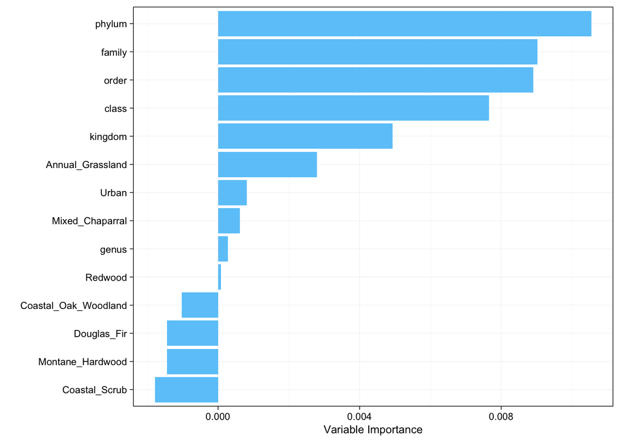

# Predictors of trends: taxon partial effects

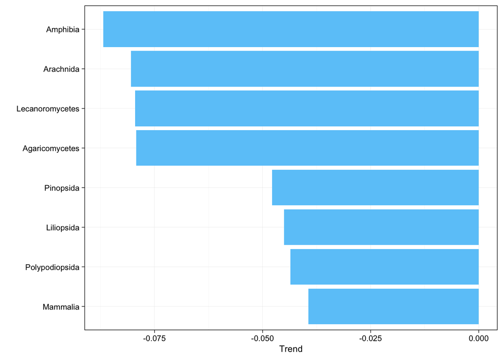

# Predictors of trends: habitat partial effects

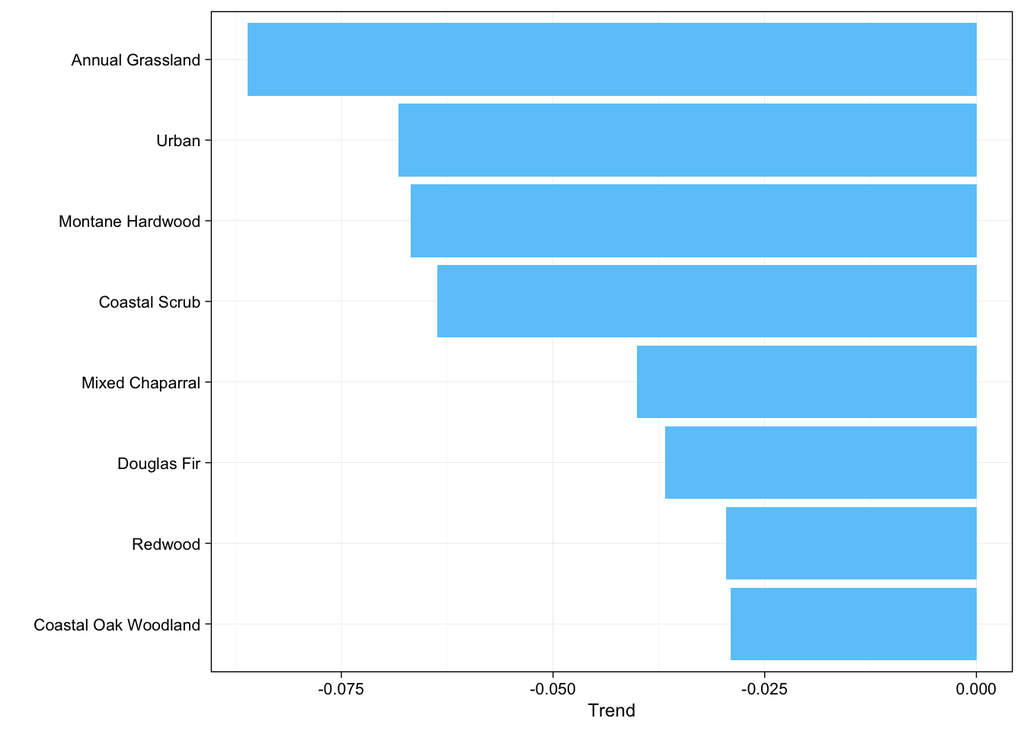